# (Gobike data exploration)

## Preliminary Wrangling

```python
# import all packages and set plots to be embedded inline
import numpy as np
import pandas as pd
import matplotlib.pyplot as plt
import seaborn as sb

%matplotlib inline
```

```python
df=pd.read_csv('201902-fordgobike-tripdata.csv')
```

```python
df.head()
```

|  | duration_sec | start_time | end_time | start_station_id | start_station_name | start_station_latitude | start_station_longitude | end_station_id | end_station_name | end_station_latitude | end_station_longitude | bike_id | user_type | member_birth_year | member_gender | bike_share_for_all_trip |
| --- | --- | --- | --- | --- | --- | --- | --- | --- | --- | --- | --- | --- | --- | --- | --- | --- |
| 0 | 52185 | 2019-02-28 17:32:10.1450 | 2019-03-01 08:01:55.9750 | 21.0 | Montgomery St BART Station (Market St at 2nd St) | 37.789625 | -122.400811 | 13.0 | Commercial St at Montgomery St | 37.794231 | -122.402923 | 4902 | Customer | 1984.0 | Male | No |
| 1 | 42521 | 2019-02-28 18:53:21.7890 | 2019-03-01 06:42:03.0560 | 23.0 | The Embarcadero at Steuart St | 37.791464 | -122.391034 | 81.0 | Berry St at 4th St | 37.775880 | -122.393170 | 2535 | Customer | NaN | NaN | No |
| 2 | 61854 | 2019-02-28 12:13:13.2180 | 2019-03-01 05:24:08.1460 | 86.0 | Market St at Dolores St | 37.769305 | -122.426826 | 3.0 | Powell St BART Station (Market St at 4th St) | 37.786375 | -122.404904 | 5905 | Customer | 1972.0 | Male | No |
| 3 | 36490 | 2019-02-28 17:54:26.0100 | 2019-03-01 04:02:36.8420 | 375.0 | Grove St at Masonic Ave | 37.774836 | -122.446546 | 70.0 | Central Ave at Fell St | 37.773311 | -122.444293 | 6638 | Subscriber | 1989.0 | Other | No |
| 4 | 1585 | 2019-02-28 23:54:18.5490 | 2019-03-01 00:20:44.0740 | 7.0 | Frank H Ogawa Plaza | 37.804562 | -122.271738 | 222.0 | 10th Ave at E 15th St | 37.792714 | -122.248780 | 4898 | Subscriber | 1974.0 | Male | Yes |

```python
df.dtypes
```

```
duration_sec                 int64
start_time                  object
end_time                    object
start_station_id           float64
start_station_name          object
start_station_latitude     float64
start_station_longitude    float64
end_station_id             float64
end_station_name            object
end_station_latitude       float64
end_station_longitude      float64
bike_id                      int64
user_type                   object
member_birth_year          float64
member_gender               object
bike_share_for_all_trip     object
dtype: object
```

```python
df.shape
```

[output not shown]

```python
#To investigate in depth date and time facto we need to make some derived columns
for i in df[['start_time', 'end_time']]:
    df[i]=pd.to_datetime(df[i])
    df['{}'.format(i)+'_year'] = df[i].dt.year
    df['{}'.format(i)+'_month'] = df[i].dt.month
    df['{}'.format(i)+'_month_day'] = df[i].dt.day
    df['{}'.format(i)+'_day'] = df[i].dt.day_name()
    df['{}'.format(i)+'_hour'] = df[i].dt.hour
```

```python
df.dtypes
```

```
duration_sec                        int64
start_time                 datetime64[ns]
end_time                   datetime64[ns]
start_station_id                  float64
start_station_name                 object
start_station_latitude            float64
start_station_longitude           float64
end_station_id                    float64
end_station_name                   object
end_station_latitude              float64
end_station_longitude             float64
bike_id                             int64
user_type                          object
member_birth_year                 float64
member_gender                      object
bike_share_for_all_trip            object
start_time_year                     int64
start_time_month                    int64
start_time_month_day                int64
start_time_day                     object
start_time_hour                     int64
end_time_year                       int64
end_time_month                      int64
end_time_month_day                  int64
end_time_day                       object
end_time_hour                       int64
dtype: object
```

```python
df.head()
```

|  | duration_sec | start_time | end_time | start_station_id | start_station_name | start_station_latitude | start_station_longitude | end_station_id | end_station_name | end_station_latitude | ... | start_time_year | start_time_month | start_time_month_day | start_time_day | start_time_hour | end_time_year | end_time_month | end_time_month_day | end_time_day | end_time_hour |
| --- | --- | --- | --- | --- | --- | --- | --- | --- | --- | --- | --- | --- | --- | --- | --- | --- | --- | --- | --- | --- | --- |
| 0 | 52185 | 2019-02-28 17:32:10.145 | 2019-03-01 08:01:55.975 | 21.0 | Montgomery St BART Station (Market St at 2nd St) | 37.789625 | -122.400811 | 13.0 | Commercial St at Montgomery St | 37.794231 | ... | 2019 | 2 | 28 | Thursday | 17 | 2019 | 3 | 1 | Friday | 8 |
| 1 | 42521 | 2019-02-28 18:53:21.789 | 2019-03-01 06:42:03.056 | 23.0 | The Embarcadero at Steuart St | 37.791464 | -122.391034 | 81.0 | Berry St at 4th St | 37.775880 | ... | 2019 | 2 | 28 | Thursday | 18 | 2019 | 3 | 1 | Friday | 6 |
| 2 | 61854 | 2019-02-28 12:13:13.218 | 2019-03-01 05:24:08.146 | 86.0 | Market St at Dolores St | 37.769305 | -122.426826 | 3.0 | Powell St BART Station (Market St at 4th St) | 37.786375 | ... | 2019 | 2 | 28 | Thursday | 12 | 2019 | 3 | 1 | Friday | 5 |
| 3 | 36490 | 2019-02-28 17:54:26.010 | 2019-03-01 04:02:36.842 | 375.0 | Grove St at Masonic Ave | 37.774836 | -122.446546 | 70.0 | Central Ave at Fell St | 37.773311 | ... | 2019 | 2 | 28 | Thursday | 17 | 2019 | 3 | 1 | Friday | 4 |
| 4 | 1585 | 2019-02-28 23:54:18.549 | 2019-03-01 00:20:44.074 | 7.0 | Frank H Ogawa Plaza | 37.804562 | -122.271738 | 222.0 | 10th Ave at E 15th St | 37.792714 | ... | 2019 | 2 | 28 | Thursday | 23 | 2019 | 3 | 1 | Friday | 0 |

5 rows × 26 columns

```python
#now we don't need the old columns
df.drop(['start_time', 'end_time'],axis=1)
```

|  | duration_sec | start_station_id | start_station_name | start_station_latitude | start_station_longitude | end_station_id | end_station_name | end_station_latitude | end_station_longitude | bike_id | ... | start_time_year | start_time_month | start_time_month_day | start_time_day | start_time_hour | end_time_year | end_time_month | end_time_month_day | end_time_day | end_time_hour |
| --- | --- | --- | --- | --- | --- | --- | --- | --- | --- | --- | --- | --- | --- | --- | --- | --- | --- | --- | --- | --- | --- |
| 0 | 52185 | 21.0 | Montgomery St BART Station (Market St at 2nd St) | 37.789625 | -122.400811 | 13.0 | Commercial St at Montgomery St | 37.794231 | -122.402923 | 4902 | ... | 2019 | 2 | 28 | Thursday | 17 | 2019 | 3 | 1 | Friday | 8 |
| 1 | 42521 | 23.0 | The Embarcadero at Steuart St | 37.791464 | -122.391034 | 81.0 | Berry St at 4th St | 37.775880 | -122.393170 | 2535 | ... | 2019 | 2 | 28 | Thursday | 18 | 2019 | 3 | 1 | Friday | 6 |
| 2 | 61854 | 86.0 | Market St at Dolores St | 37.769305 | -122.426826 | 3.0 | Powell St BART Station (Market St at 4th St) | 37.786375 | -122.404904 | 5905 | ... | 2019 | 2 | 28 | Thursday | 12 | 2019 | 3 | 1 | Friday | 5 |
| 3 | 36490 | 375.0 | Grove St at Masonic Ave | 37.774836 | -122.446546 | 70.0 | Central Ave at Fell St | 37.773311 | -122.444293 | 6638 | ... | 2019 | 2 | 28 | Thursday | 17 | 2019 | 3 | 1 | Friday | 4 |
| 4 | 1585 | 7.0 | Frank H Ogawa Plaza | 37.804562 | -122.271738 | 222.0 | 10th Ave at E 15th St | 37.792714 | -122.248780 | 4898 | ... | 2019 | 2 | 28 | Thursday | 23 | 2019 | 3 | 1 | Friday | 0 |
| ... | ... | ... | ... | ... | ... | ... | ... | ... | ... | ... | ... | ... | ... | ... | ... | ... | ... | ... | ... | ... | ... |
| 183407 | 480 | 27.0 | Beale St at Harrison St | 37.788059 | -122.391865 | 324.0 | Union Square (Powell St at Post St) | 37.788300 | -122.408531 | 4832 | ... | 2019 | 2 | 1 | Friday | 0 | 2019 | 2 | 1 | Friday | 0 |
| 183408 | 313 | 21.0 | Montgomery St BART Station (Market St at 2nd St) | 37.789625 | -122.400811 | 66.0 | 3rd St at Townsend St | 37.778742 | -122.392741 | 4960 | ... | 2019 | 2 | 1 | Friday | 0 | 2019 | 2 | 1 | Friday | 0 |
| 183409 | 141 | 278.0 | The Alameda at Bush St | 37.331932 | -121.904888 | 277.0 | Morrison Ave at Julian St | 37.333658 | -121.908586 | 3824 | ... | 2019 | 2 | 1 | Friday | 0 | 2019 | 2 | 1 | Friday | 0 |
| 183410 | 139 | 220.0 | San Pablo Ave at MLK Jr Way | 37.811351 | -122.273422 | 216.0 | San Pablo Ave at 27th St | 37.817827 | -122.275698 | 5095 | ... | 2019 | 2 | 1 | Friday | 0 | 2019 | 2 | 1 | Friday | 0 |
| 183411 | 271 | 24.0 | Spear St at Folsom St | 37.789677 | -122.390428 | 37.0 | 2nd St at Folsom St | 37.785000 | -122.395936 | 1057 | ... | 2019 | 2 | 1 | Friday | 0 | 2019 | 2 | 1 | Friday | 0 |

183412 rows × 24 columns

```python
#drop nulls for better performance
df.dropna()
```

|  | duration_sec | start_time | end_time | start_station_id | start_station_name | start_station_latitude | start_station_longitude | end_station_id | end_station_name | end_station_latitude | ... | start_time_year | start_time_month | start_time_month_day | start_time_day | start_time_hour | end_time_year | end_time_month | end_time_month_day | end_time_day | end_time_hour |
| --- | --- | --- | --- | --- | --- | --- | --- | --- | --- | --- | --- | --- | --- | --- | --- | --- | --- | --- | --- | --- | --- |
| 0 | 52185 | 2019-02-28 17:32:10.145 | 2019-03-01 08:01:55.975 | 21.0 | Montgomery St BART Station (Market St at 2nd St) | 37.789625 | -122.400811 | 13.0 | Commercial St at Montgomery St | 37.794231 | ... | 2019 | 2 | 28 | Thursday | 17 | 2019 | 3 | 1 | Friday | 8 |
| 2 | 61854 | 2019-02-28 12:13:13.218 | 2019-03-01 05:24:08.146 | 86.0 | Market St at Dolores St | 37.769305 | -122.426826 | 3.0 | Powell St BART Station (Market St at 4th St) | 37.786375 | ... | 2019 | 2 | 28 | Thursday | 12 | 2019 | 3 | 1 | Friday | 5 |
| 3 | 36490 | 2019-02-28 17:54:26.010 | 2019-03-01 04:02:36.842 | 375.0 | Grove St at Masonic Ave | 37.774836 | -122.446546 | 70.0 | Central Ave at Fell St | 37.773311 | ... | 2019 | 2 | 28 | Thursday | 17 | 2019 | 3 | 1 | Friday | 4 |
| 4 | 1585 | 2019-02-28 23:54:18.549 | 2019-03-01 00:20:44.074 | 7.0 | Frank H Ogawa Plaza | 37.804562 | -122.271738 | 222.0 | 10th Ave at E 15th St | 37.792714 | ... | 2019 | 2 | 28 | Thursday | 23 | 2019 | 3 | 1 | Friday | 0 |
| 5 | 1793 | 2019-02-28 23:49:58.632 | 2019-03-01 00:19:51.760 | 93.0 | 4th St at Mission Bay Blvd S | 37.770407 | -122.391198 | 323.0 | Broadway at Kearny | 37.798014 | ... | 2019 | 2 | 28 | Thursday | 23 | 2019 | 3 | 1 | Friday | 0 |
| ... | ... | ... | ... | ... | ... | ... | ... | ... | ... | ... | ... | ... | ... | ... | ... | ... | ... | ... | ... | ... | ... |
| 183407 | 480 | 2019-02-01 00:04:49.724 | 2019-02-01 00:12:50.034 | 27.0 | Beale St at Harrison St | 37.788059 | -122.391865 | 324.0 | Union Square (Powell St at Post St) | 37.788300 | ... | 2019 | 2 | 1 | Friday | 0 | 2019 | 2 | 1 | Friday | 0 |
| 183408 | 313 | 2019-02-01 00:05:34.744 | 2019-02-01 00:10:48.502 | 21.0 | Montgomery St BART Station (Market St at 2nd St) | 37.789625 | -122.400811 | 66.0 | 3rd St at Townsend St | 37.778742 | ... | 2019 | 2 | 1 | Friday | 0 | 2019 | 2 | 1 | Friday | 0 |
| 183409 | 141 | 2019-02-01 00:06:05.549 | 2019-02-01 00:08:27.220 | 278.0 | The Alameda at Bush St | 37.331932 | -121.904888 | 277.0 | Morrison Ave at Julian St | 37.333658 | ... | 2019 | 2 | 1 | Friday | 0 | 2019 | 2 | 1 | Friday | 0 |
| 183410 | 139 | 2019-02-01 00:05:34.360 | 2019-02-01 00:07:54.287 | 220.0 | San Pablo Ave at MLK Jr Way | 37.811351 | -122.273422 | 216.0 | San Pablo Ave at 27th St | 37.817827 | ... | 2019 | 2 | 1 | Friday | 0 | 2019 | 2 | 1 | Friday | 0 |
| 183411 | 271 | 2019-02-01 00:00:20.636 | 2019-02-01 00:04:52.058 | 24.0 | Spear St at Folsom St | 37.789677 | -122.390428 | 37.0 | 2nd St at Folsom St | 37.785000 | ... | 2019 | 2 | 1 | Friday | 0 | 2019 | 2 | 1 | Friday | 0 |

174952 rows × 26 columns

```python
#remove duplicates for accuracy
df.drop_duplicates()
```

[output not shown]

### What is/are the main feature(s) of interest in your dataset?

> I am intersted in investigating patterns of operations regarding duration and popular hours and days for hiring. I am also intersted in user ages and gender.

### What features in the dataset do you think will help support your investigation into your feature(s) of interest?

> I'll make use of user columns, duration time & date columns

## Univariate Exploration

> What is the gender of most users?

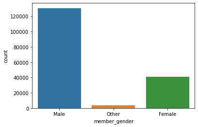

```python
sb.countplot(data = df, x = 'member_gender')
```

Observation: It's obvious that male users are much more than female users.

Are most of users customers or subscribers?

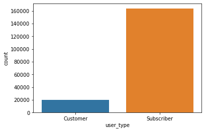

```python
sb.countplot(data = df, x = 'user_type')
```

Obsetrvation: Most cusers are subscibers they are about 8 times more than customers

In what age stage are our users?

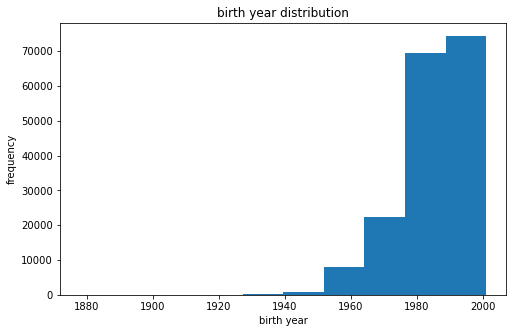

```python
plt.figure(figsize=[8, 5])
plt.hist(data = df, x = 'member_birth_year')
plt.xlabel('birth year')
plt.ylabel('frequency')
plt.title('birth year distribution')
plt.show()
```

There are outliers that have shifted the plot, so we will limit the range for better investigation.

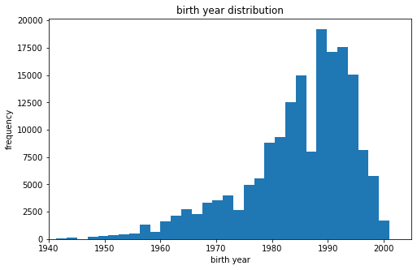

```python
#Investigation of birth year occurence
plt.figure(figsize=[8, 5])
plt.hist(data = df, x = 'member_birth_year',bins=66)
plt.xlim([1940,2005])
plt.xlabel('birth year')
plt.ylabel('frequency')
plt.title('birth year distribution')
plt.show()
```

Observation: There are trending between 1975 till 1997 with drop at nearly 1989 then reaches its peak at 1990 and gradually decrease till bsfore 2000

For how long do users hire bikes?

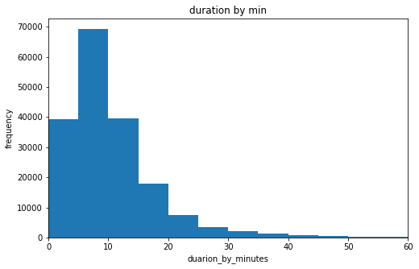

```python
i=df['duration_sec']/60
plt.figure(figsize=[8, 5])
bins=np.arange(0,i.max()+5,5)
plt.hist( x = i,bins=bins)
plt.xlabel('duarion_by_minutes')
plt.ylabel('frequency')
plt.title('duration by min')
plt.xlim([0,60])
plt.show()
```

Observation: most users hire for 10 minutes more or less 5 minutes and less users hire for longer durations

Is there dayweeks more common for hiring than others?

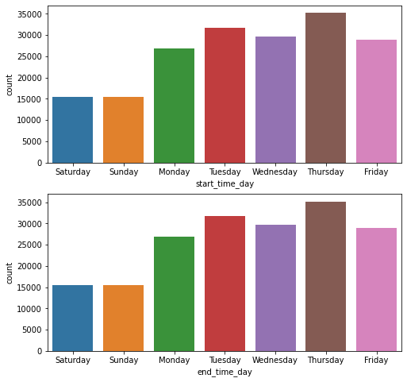

```python
fig, ax = plt.subplots(nrows=2, figsize = [8,8])
days_order=['Saturday','Sunday','Monday','Tuesday','Wednesday','Thursday','Friday']
sb.countplot(data = df, x = 'start_time_day',ax=ax[0],order=days_order)
sb.countplot(data = df, x = 'end_time_day',ax=ax[1],order=days_order)
```

Observation: Surprisingly Tuesdays and Thursdays are more likely for hiring than Saturdays and Sundays.

Is there trending year in the data?

```python
df['end_time_year'].value_counts()
```

```
2019    183412
Name: end_time_year, dtype: int64
```

The data only describes 2019

Is there trending month in the data?

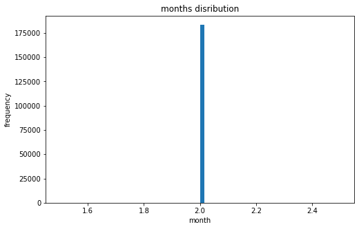

```python
#sb.countplot(data = df, x = 'start_time_month')

plt.figure(figsize=[8, 5])
plt.hist(data = df, x = 'start_time_month',bins=66)
plt.xlabel('month')
plt.ylabel('frequency')
plt.title('months disribution')
plt.show()
```

The dataset are only for Febrauary!

```python
#to make sure
df['start_time_month'].value_counts()
```

```
2    183412
Name: start_time_month, dtype: int64
```

Is there trending hours through the day?

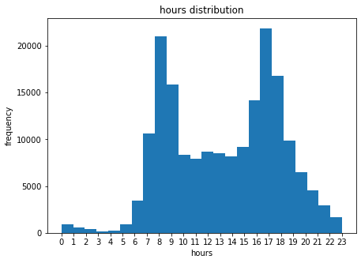

```python
#investigation of hourly rate
a=np.arange(0,24,1)
plt.figure(figsize=[7, 5])
plt.hist(data = df, x = 'start_time_hour',bins=24)
plt.xticks(np.arange(0,24,1),a)
plt.xlabel('hours')
plt.ylabel('frequency')
plt.title('hours distribution')
plt.show()
```

### Discuss the distribution(s) of your variable(s) of interest. Were there any unusual points? Did you need to perform any transformations?

> Most of users birth year lie betweenn 1970 and 2000 with intersting drop in 1990 and rise again then gradual falling after 1992  
> It's clear that 10 minutes trips are most common with gradual decrease in recurrence with increase of period.  
> Rerding daily rate Thursday comes first with Tueday scondly!Tuesday is middle week but with higher rate than weekend.  
> For hourly rate we noted that there is clear rise at sunrise and sunset.

### Of the features you investigated, were there any unusual distributions? Did you perform any operations on the data to tidy, adjust, or change the form of the data? If so, why did you do this?

The dataset are only for 2019!

## Bivariate Exploration

investigation of relation between all variables.

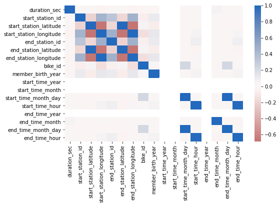

```python
plt.figure(figsize = [8, 5])
sb.heatmap(df.corr(), annot =False,
           cmap = 'vlag_r', center = 0)
plt.show()
```

Observation:There are no noticable relation between those variables

How trip duration vary along the day?

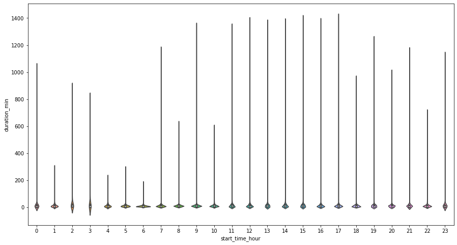

```python
#Trying to investigate the relation between duration and the hour of start
i=df['duration_sec']/60
plt.subplots(figsize = [15,8])
sb.violinplot( x= df['start_time_hour'], y= i)
plt.ylabel('duration_min')
plt.show()
```

Observation: Outliers make it hard to detect change.

Ware going to set limit for betted observation.

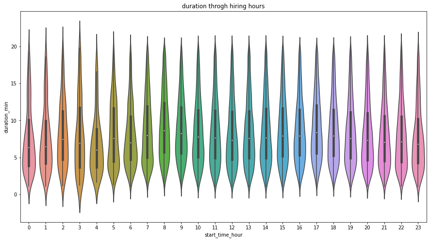

```python
#we see that outliers affected the plot so we will exclude values above 20 as they are negelecable
i=df['duration_sec']/60
plt.subplots(figsize = [15,8])
sb.violinplot( x= df['start_time_hour'], y= i[i<20])
plt.ylabel('duration_min')
plt.title("duration throgh hiring hours")
plt.show()
```

Observation: Longer durations seems to appear at night hours 2,3,5 and 8:00 am also at 5:00 pm.  
average of duration decreases at 4:00 am and shorter duration are more common. Most hours follow somekind similar duration patterns

How duration of trip vary between weekdays?

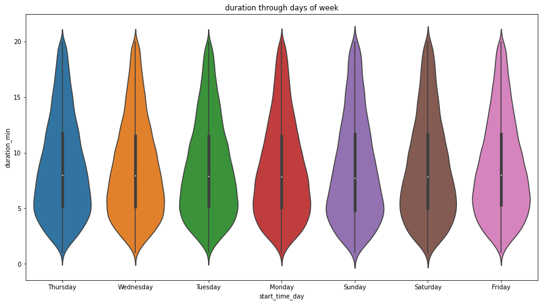

```python
#investigation of relation between day of week and duration
i=df['duration_sec']/60
plt.subplots(figsize = [15,8])
sb.violinplot( x= df['start_time_day'], y= i[i<20])
plt.ylabel('duration_min')
plt.title('duration through days of week')
plt.show()
```

Observation: patterns don't differ much between days only minor differnces.

### Did you observe any interesting relationships between the other features (not the main feature(s) of interest)?

> I didn't observe any!

## Multivariate Exploration

> Is there difference between different gender duration of trip over weekdays?

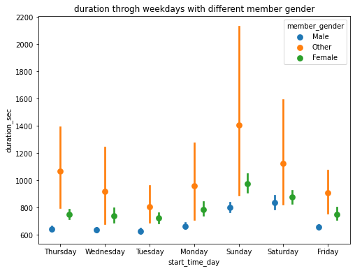

```python
fig = plt.figure(figsize = [8,6])
ax = sb.pointplot(df['start_time_day'],df['duration_sec'], hue = df['member_gender'], linestyles = '', dodge = 0.4)
plt.title('duration throgh weekdays with different member gender')
plt.show()
```

Observation: Females tend to hure longer trips than males all over the weekk with Sundays and Saturdays scoring hiher average for both.

What about user type effect on duration allover the week?

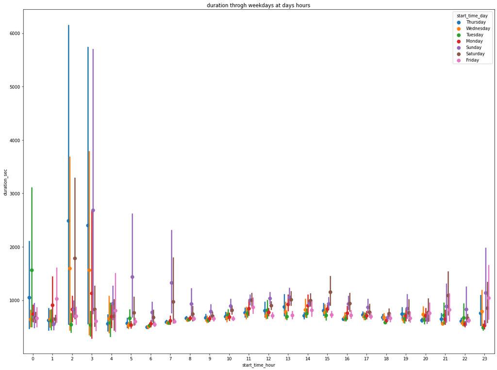

```python
fig = plt.figure(figsize = [20,15])
ax = sb.pointplot(df['start_time_hour'],df['duration_sec'], hue = df['start_time_day'], linestyles = '', dodge = 0.4)
plt.title('duration throgh weekdays at days hours')
plt.show()
```

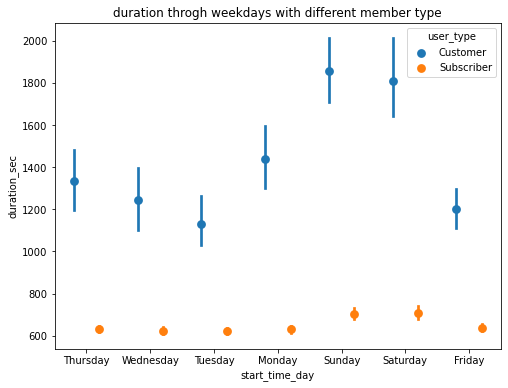

```python
fig = plt.figure(figsize = [8,6])
ax = sb.pointplot(df['start_time_day'],df['duration_sec'], hue = df['user_type'], linestyles = '', dodge = 0.4)
plt.title('duration throgh weekdays with different member type')
plt.show()
```

Observation: Customers have longer trip much more than subscribers specially on Saturdays and Sundays.

How do users of different ages and gender vary in their trip duraion?

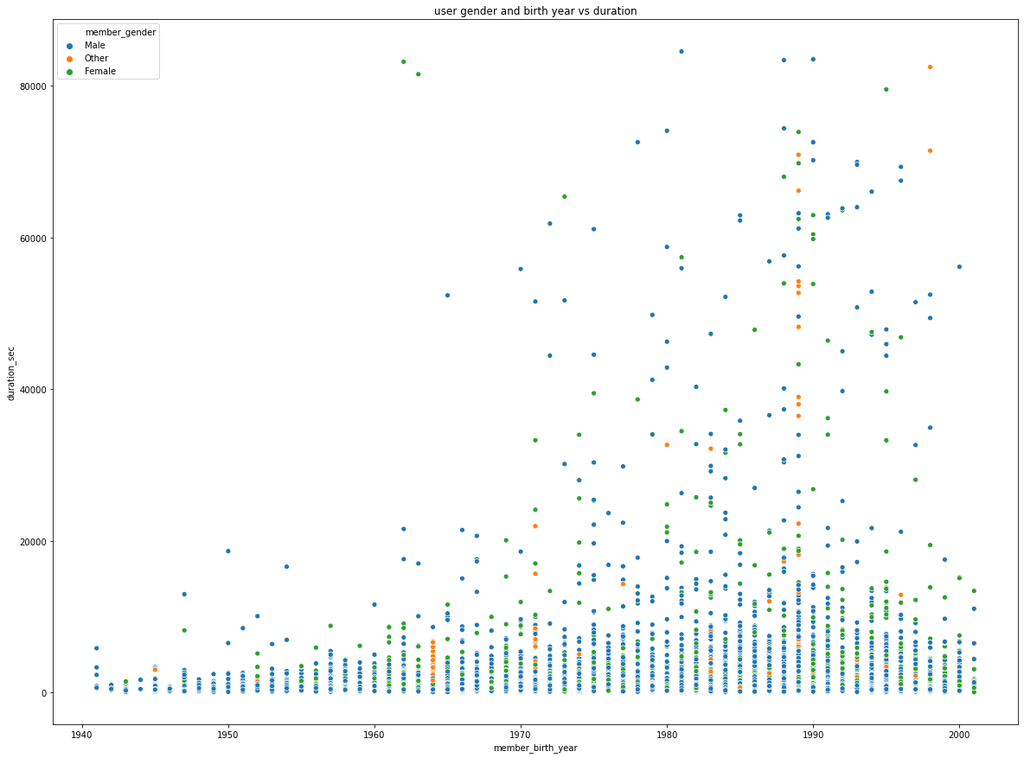

```python
avg_ages=df['member_birth_year'][df['member_birth_year']>1940]
fig = plt.figure(figsize = [20,15])
sb.scatterplot(data=df,x=avg_ages, y="duration_sec",hue='member_gender')
plt.title('user gender and birth year vs duration')
```

Observation: both men aand women had long trips but more common with those who were born after 1970 and before 1997.

### Were there any interesting or surprising interactions between features?

> Very old people didn't have long trips and also the younger, middle aged did.  
> Females scored longer average duration of trips.  
> Night and doon hours till 7:00 am had the longest trips especially weekends, Tuesdays and Thursdays nights